# Cardiac Graphs

## Parts of the ECG Wave

The heart is stimulated electrically as it contracts.

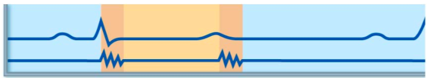

P

Q

R

S

T

lub

dupp

The *lub* sound is the closing of the AV valves, while the *dupp* sound is the slamming shut of the semilunar valves.

We can remember that the *P* spike is the atrial depolarization, while the *QRS* complex depicts ventricular depolarization.

## Pressure graphs

**Some key terminology to remember:** *systole* refers to when the chambers of the heart contract and thus pump blood, while *diastole* refers to the relaxation of the chambers that allows filling with blood.

### Aorta

dicrotic notch

80

pressure (mmHg)

40

### Left atrium

atrial systole

80

pressure (mmHg)

40

### Left ventricle

ventricular systole

80

pressure (mmHg)

40

## Volume graph

As the heart contracts and relaxes, the volume of the chambers of the heart change. Here, we analyze the volume of the ventricles.

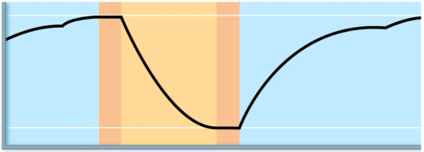

1

2

end systolic volume

end diastolic volume

stroke volume

ventricular volume (mL)

120

30

1. Isovolumetric contraction  
2. Isovolumetric relaxation

<sub>Copyright: 2016 Pearson Education</sub>